© Bản quyền thuộc về Quantopian Inc.  
© Bản quyền sửa đổi thuộc về AI Cafe¹  
Giấy phép [Creative Commons Attribution 4.0](https://creativecommons.org/licenses/by/4.0/legalcode).  
[Khuyến cáo](https://aicafe.one/khuyen-cao/)

# Ước lượng ma trận hiệp phương sai

By Christopher van Hoecke and Max Margenot

Edited by AI Cafe¹

Biến động lâu nay luôn là một vấn đề khó khăn đối với các nhà đầu tư trên thị trường. Việc đo lường biến động một cách chính xác sẽ cho phép mô hình hóa lợi nhuận một cách chính xác hơn và tạo ra các khoản đầu tư ổn định hơn, dẫn đến lợi nhuận lớn hơn, nhưng dự đoán biến động một cách chính xác là một bài toán khó.

## Đo Lường Biến Động

Biến động cần phải có cái nhìn hướng tới tương lai và mang tính dự đoán để đưa ra những quyết định thông minh. Thật không may, việc chỉ đơn giản lấy độ lệch chuẩn lịch sử của lợi suất của một tài sản cá nhân là không đủ khi chúng ta xem xét nhu cầu về độ bền vững trong tương lai. Khi chúng ta mở rộng vấn đề đến mức cần dự đoán biến động cho nhiều tài sản, điều này trở nên khó khăn hơn nữa.

Để mô hình hóa cách mà một danh mục đầu tư thay đổi một cách tổng thể, điều quan trọng là không chỉ nhìn vào biến động của từng tài sản trong danh mục, mà còn phải xem xét các hiệp phương sai theo cặp giữa mọi tài sản có liên quan. Mối quan hệ giữa hai hoặc nhiều tài sản cung cấp những thông tin quý giá và một con đường hướng tới việc giảm thiểu biến động tổng thể của danh mục đầu tư. Một số lượng lớn tài sản với hiệp phương sai thấp sẽ đảm bảo rằng chúng giảm hoặc tăng một cách độc lập với nhau. Các tài sản độc lập sẽ có ít tác động hơn đến biến động của danh mục đầu tư của chúng ta vì chúng mang lại sự đa dạng thực sự và giúp chúng ta tránh rủi ro tập trung vị thế.

## Hiệp phương sai

Trong thống kê và xác suất, hiệp phương sai là một thước đo sự biến đổi chung của hai biến ngẫu nhiên. Khi các biến ngẫu nhiên thể hiện hành vi tương tự, thường sẽ có hiệp phương sai cao giữa chúng. Về mặt toán học, chúng ta biểu diễn hiệp phương sai của X đối với Y như sau:

$$ COV(X, Y) = E[(X - E[X])(Y - E[Y])]$$

Lưu ý rằng nếu chúng ta lấy hiệp phương sai của $X$ với chính nó, chúng ta sẽ nhận được:

$$ COV(X, X) = E[(X - E[X])(X - E[X])] = E[(X - E[X])^2] = VAR(X) $$

Chúng ta có thể sử dụng hiệp phương sai để định lượng sự tương đồng giữa các tài sản khác nhau theo cách tương tự. Nếu hai tài sản có hiệp phương sai cao, chúng thường sẽ có hành vi giống nhau. Các tài sản có hiệp phương sai đặc biệt cao có thể thay thế lẫn nhau.

Ma trận hiệp phương sai cấu thành nền tảng của lý thuyết Danh mục Hiện đại (MPT). MPT tập trung vào việc tối đa hóa lợi nhuận cho một mức độ rủi ro nhất định, làm cho các phương pháp mà chúng ta sử dụng để ước lượng rủi ro đó trở nên thiết yếu. Chúng ta sử dụng hiệp phương sai để định lượng rủi ro chung của các tài sản, hình thành cách chúng ta nhìn nhận rủi ro của toàn bộ danh mục. Điều quan trọng là đầu tư vào các tài sản có hiệp phương sai cặp cao sẽ cung cấp ít sự đa dạng hóa vì sự biến động của chúng liên quan chặt chẽ với nhau.

```python
import numpy as np
import pandas as pd
import matplotlib.pyplot as plt
import seaborn as sns
from sklearn import covariance
```

Hãy tính hiệp phương sai của hai biến có liên quan chặt chẽ, $X$ và $Y$. Giả sử rằng $X$ là một tập hợp được chọn ngẫu nhiên và $Y = 5X + \epsilon$, trong đó $\epsilon$ là một nhiễu bổ sung. Chúng ta có thể tính hiệp phương sai sử dụng công thức trên để có cái nhìn rõ hơn về cách mà $X$ phát triển liên quan đến tài sản $Y$.

```python
# Generate random values of x
X = np.random.normal(size = 1000)
epsilon = np.random.normal(0, 3, size = len(X))
Y = 5*X + epsilon

product = (X - np.mean(X))*(Y - np.mean(Y))
expected_value = np.mean(product)

print('Value of the covariance between X and Y:', expected_value)
```

```
Value of the covariance between X and Y: 5.069649312628735
```

Chúng ta cũng có thể tính toán hiệp phương sai giữa $X$ và $Y$ bằng một hàm duy nhất

```python
np.cov([X, Y])
```

```
array([[ 1.03107379,  5.07472404],
       [ 5.07472404, 34.03489695]])
```

Kết quả cho chúng ta ma trận hiệp phương sai giữa $X$ và $Y$. Các phần tử chéo là phương sai tương ứng của chúng và các chỉ số $(i, j)$ đề cập đến hiệp phương sai giữa các tài sản được đánh chỉ số $i$ và $j$.

```python
print(np.var(X), np.var(Y))
```

```
1.0300427112692534 34.000862050931886
```

Trong trường hợp này, chúng ta chỉ có hai tài sản nên chỉ có các chỉ số $(0, 1)$ và $(1, 0)$. Ma trận hiệp phương sai là đối xứng, vì $COV(X, Y) = COV(Y, X)$, đó là lý do tại sao các giá trị ngoài đường chéo phản chiếu nhau.

Chúng ta có thể nghĩ một cách trực quan về điều này như là mức độ thay đổi của $Y$ khi $X$ thay đổi và ngược lại. Do đó, giá trị hiệp phương sai của chúng ta khoảng 5 có thể đã được dự đoán từ định nghĩa về mối quan hệ giữa $X$ và $Y$.

Dưới đây là một biểu đồ phân tán giữa $X$ và $Y$ với một đường hồi quy tốt nhất ở giữa.

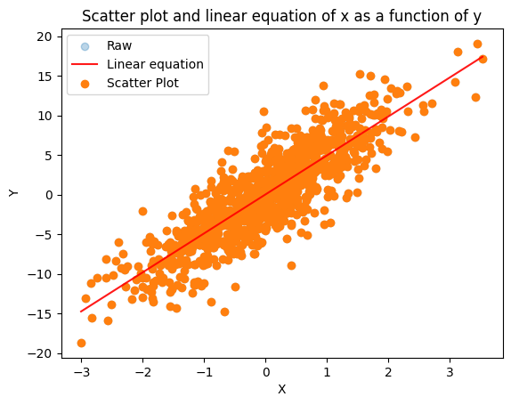

```python
# scatter plot of X and y
from statsmodels import regression
import statsmodels.api as sm
def linreg(X,Y):
    # Running the linear regression
    X = sm.add_constant(X)
    model = regression.linear_model.OLS(Y, X).fit()
    a = model.params[0]
    b = model.params[1]
    X = X[:, 1]

    # Return summary of the regression and plot results
    X2 = np.linspace(X.min(), X.max(), 100)
    Y_hat = X2 * b + a
    plt.scatter(X, Y, alpha=0.3) # Plot the raw data
    plt.plot(X2, Y_hat, 'r', alpha=0.9);  # Add the regression line, colored in red
    plt.xlabel('X Value')
    plt.ylabel('Y Value')
    return model.summary()

linreg(X, Y)
plt.scatter(X, Y)
plt.title('Scatter plot and linear equation of x as a function of y')
plt.xlabel('X')
plt.ylabel('Y')
plt.legend(['Raw','Linear equation', 'Scatter Plot']);
```

Giữa hiệp phương sai, hồi quy tuyến tính và kiến thức của chúng ta về cách mà $X$ và $Y$ có mối liên hệ với nhau, chúng ta có thể dễ dàng đánh giá mối quan hệ giữa các biến giả lập của mình. Với dữ liệu thực, có hai yếu tố chính làm phức tạp thêm vấn đề. Thứ nhất là chúng ta đang xem xét nhiều mối quan hệ hơn. Thứ hai là chúng ta không biết bất kỳ mối quan hệ cơ bản nào của chúng. Những trở ngại này cho thấy lợi ích của việc có các ước lượng chính xác về ma trận hiệp phương sai.

## Ma trận hiệp phương sai

Khi số lượng tài sản mà chúng ta quan tâm tăng lên, số chiều của ma trận hiệp phương sai mô tả mối quan hệ của chúng cũng tăng theo. Nếu chúng ta lấy hiệp phương sai giữa $N$ tài sản, chúng ta sẽ có được một ma trận hiệp phương sai kích thước $N \times N$. Điều này cho phép chúng ta diễn đạt một cách hiệu quả mối quan hệ giữa nhiều mảng cùng một lúc. Tương tự như trường hợp đơn giản $2\times 2$, phần chéo thứ $i$ là phương sai của tài sản thứ $i$ và các giá trị tại $(i, j)$ và $(j, i)$ đề cập đến hiệp phương sai giữa tài sản $i$ và tài sản $j$. Chúng ta thể hiện điều này bằng ký hiệu sau:

$$ \Sigma = \left[\begin{matrix} VAR(X_1) & COV(X_1, X_2) & \cdots & COV(X_1, X_N) \\ COV(X_2, X_0) & VAR(X_2) & \cdots & COV(X_2, X_N) \\ \vdots & \vdots & \ddots & \vdots \\ COV(X_N, X_1) & COV(X_N, X_2) & \cdots & VAR(X_N) \end{matrix}\right] $$

Khi cố gắng tìm độ tương quan của nhiều tài sản, chúng ta nhanh chóng nhận ra lý do tại sao ký hiệu ma trận lại được ưa chuộng hơn.

```python
# Cài thư viện lấy dữ liệu miễn phí
!curl -fsSLO https://raw.githubusercontent.com/algo-stocks/data/master/data.py
```

```python
from data import get_prices

start = '2025-01-01'
end = '2025-02-01'

prices = get_prices('FPT', 'VCB', 'BID', 'HPG', start_date=start, end_date=end)
returns = prices.pct_change()[1:]

print('Covariance matrix:')
print(returns.cov())
```

```
Covariance matrix:
          FPT       VCB       BID       HPG
FPT  0.000156  0.000031  0.000068  0.000078
VCB  0.000031  0.000049  0.000014  0.000022
BID  0.000068  0.000014  0.000185  0.000039
HPG  0.000078  0.000022  0.000039  0.000132
```

## Tại sao tất cả những điều này lại quan trọng?

Chúng ta đo lường hiệp phương sai của các tài sản trong danh mục đầu tư của mình để đảm bảo rằng chúng ta có một bức tranh chính xác về các rủi ro liên quan đến việc nắm giữ những tài sản đó cùng nhau. Chúng ta muốn phân bổ vốn của mình giữa các tài sản này một cách sao cho giảm thiểu sự tiếp xúc với các rủi ro liên quan đến từng tài sản riêng rẽ và trung hòa sự tiếp xúc với rủi ro hệ thống. Điều này được thực hiện thông qua quá trình tối ưu hóa danh mục đầu tư. Các quy trình tối ưu hóa danh mục đầu tư sẽ trải qua chính xác quá trình này, tìm ra trọng số phù hợp cho từng tài sản dựa trên các rủi ro của nó. Tối ưu hóa trung bình-phương sai, một yếu tố chủ chốt của MPT, thực hiện chính xác điều này.

Việc ước lượng ma trận hiệp phương sai trở nên rất quan trọng khi sử dụng các phương pháp dựa vào nó, vì chúng ta không thể biết được các mối quan hệ thống kê thực sự nằm sau các tài sản mà chúng ta đã chọn. Sự ổn định và chính xác của những ước lượng này rất cần thiết để có được trọng số ổn định phản ánh rủi ro và ý định của chúng ta.

Thật không may, cách rõ ràng nhất để tính toán ước lượng ma trận hiệp phương sai, tức là hiệp phương sai mẫu, lại nổi tiếng là không ổn định. Nếu chúng ta có ít quan sát thời gian của các tài sản hơn số lượng tài sản ($T < N$), thì ước lượng trở nên đặc biệt không đáng tin cậy. Các giá trị cực trị phản ứng mạnh mẽ hơn với những thay đổi, và khi các giá trị cực trị của hiệp phương sai nhảy múa, các bộ tối ưu hóa của chúng ta bị xáo trộn, dẫn đến những trọng số không nhất quán. Đây là một vấn đề khi chúng ta cố gắng thực hiện nhiều lần cược độc lập vào nhiều tài sản để cải thiện sự tiếp xúc rủi ro của mình thông qua đa dạng hóa. Ngay cả khi chúng ta có nhiều yếu tố thời gian hơn số lượng tài sản mà chúng ta giao dịch, chúng ta vẫn có thể gặp phải các vấn đề, vì thành phần thời gian có thể trải qua nhiều chế độ khác nhau, dẫn đến các ma trận hiệp phương sai vẫn không chính xác.

Giải pháp trong nhiều trường hợp là sử dụng một công thức mạnh mẽ của ma trận hiệp phương sai. Nếu chúng ta có thể ước lượng một ma trận hiệp phương sai vẫn nắm bắt các mối quan hệ giữa các tài sản và đồng thời ổn định hơn, thì chúng ta có thể tin tưởng hơn vào kết quả của các bộ tối ưu hóa của mình. Một cách chính mà chúng ta xử lý vấn đề này là bằng cách sử dụng một hình thức ước lượng co lại nào đó.

## Các Ước Lượng Shrinkage

Khái niệm shrinkage bắt nguồn từ nhu cầu có các ma trận phương sai ổn định. Cách cơ bản mà chúng ta "shrink" một ma trận là giảm các giá trị cực trị của ma trận phương sai mẫu bằng cách kéo chúng gần hơn đến trung tâm. Thực tế, chúng ta lấy một tổ hợp tuyến tính của ma trận phương sai mẫu và một mảng hằng số đại diện cho trung tâm.

Cho một ma trận phương sai mẫu, $\textbf{S}$, giá trị trung bình, $\mu$, và hằng số shrinkage $\delta$, ma trận phương sai ước lượng được shrink lại được định nghĩa toán học như sau:

$$(1 - \delta)\textbf{S} + \delta\mu\textbf{1}$$

Chúng ta giới hạn $\delta$ sao cho $0 \leq \delta \leq 1$, làm cho điều này trở thành một trung bình có trọng số giữa ma trận phương sai mẫu và ma trận giá trị trung bình. Giá trị tối ưu của $\delta$ đã được giải nhiều lần. Đối với mục đích của chúng ta, chúng ta sẽ sử dụng công thức của Ledoit và Wolf.

## Ước Lượng Ledoit-Wolf

Trong [bài báo của họ](http://ledoit.net/honey.pdf), Ledoit và Wolf đã đề xuất một $\delta$ tối ưu:

$$\hat\delta^* \max\{0, \min\{\frac{\hat\kappa}{T},1\}\}$$

$\hat\kappa$ có một công thức toán học mà vượt quá phạm vi của bài giảng này, nhưng bạn có thể tìm thấy định nghĩa của nó trong bài báo.

Ước lượng Ledoit-Wolf là ước lượng phương sai vững chắc sử dụng $\hat\delta^*$ tối ưu này để shrink ma trận phương sai mẫu. Chúng ta có thể thực hiện nó trực tiếp từ `scikit-learn` để sử dụng dễ dàng.

```python
start = '2025-01-01'
end = '2025-02-01'

prices = get_prices('FPT', 'VCB', 'BID', 'HPG', 'MBB', 'MSN', start_date=start, end_date=end)
returns = prices.pct_change()[1:]

returns.head()
```

| date | FPT | VCB | BID | HPG | MBB | MSN |
| --- | --- | --- | --- | --- | --- | --- |
| 2025-01-03 | -0.019737 | 0.001088 | 0.000000 | -0.014815 | -0.019841 | -0.015537 |
| 2025-01-06 | 0.002013 | 0.009782 | 0.015707 | -0.020677 | -0.012147 | -0.035868 |
| 2025-01-07 | 0.005358 | -0.006458 | 0.041237 | 0.000000 | 0.020350 | -0.005952 |
| 2025-01-08 | -0.011992 | 0.001084 | -0.001238 | 0.007678 | -0.002309 | 0.013473 |
| 2025-01-09 | 0.003372 | -0.005412 | -0.009913 | -0.009524 | -0.004630 | -0.005908 |

Ở đây, chúng ta sẽ tính toán ước lượng Ledoit-Wolf trong mẫu.

```python
in_sample_lw = covariance.ledoit_wolf(returns)[0]
print(in_sample_lw)
```

```
[[1.53385063e-04 1.76969977e-05 3.94159603e-05 4.50636566e-05
  5.97067389e-05 1.95085208e-05]
 [1.76969977e-05 9.21890868e-05 8.09783526e-06 1.27538525e-05
  3.44019744e-06 1.62123323e-06]
 [3.94159603e-05 8.09783526e-06 1.70339892e-04 2.26843020e-05
  5.97968315e-05 1.29941235e-05]
 [4.50636566e-05 1.27538525e-05 2.26843020e-05 1.39581664e-04
  5.74674610e-05 7.17415321e-05]
 [5.97067389e-05 3.44019744e-06 5.97968315e-05 5.74674610e-05
  1.51851196e-04 6.02310921e-05]
 [1.95085208e-05 1.62123323e-06 1.29941235e-05 7.17415321e-05
  6.02310921e-05 2.84184420e-04]]
```

### Tính Toán Lỗi

Chúng ta có thể định lượng sự khác biệt giữa các ước lượng trong mẫu và ngoài mẫu bằng cách lấy độ chênh lệch tuyệt đối từng phần cho hai ma trận. Chúng ta biểu diễn điều này một cách toán học như sau:

$$ \frac{1}{n} \sum_{i=1}^{n} |a_i - b_i| $$

Đầu tiên, chúng ta tính toán ước lượng ngoài mẫu và sau đó so sánh.

```python
oos_start = '2025-02-01'
oos_end = '2025-03-01'

oos_prices = get_prices('FPT', 'VCB', 'BID', 'HPG', 'MBB', 'MSN', start_date=oos_start, end_date=oos_end)
oos_returns = oos_prices.pct_change()[1:]
out_sample_lw = covariance.ledoit_wolf(oos_returns)[0]

lw_errors = sum(abs(np.subtract(in_sample_lw, out_sample_lw)))
print("Average Ledoit-Wolf error:", np.mean(lw_errors))
```

```
Average Ledoit-Wolf error: 0.00022519412008170105
```

### So sánh với Ma Trận Mẫu

Chúng ta có thể kiểm tra mức độ cải thiện bằng cách so sánh các sai số với các sai số của hiệp phương sai mẫu.

```python
sample_errors = sum(abs(np.subtract(returns.cov().values, oos_returns.cov().values)))
print('Average sample covariance error:', np.mean(sample_errors))
```

```
Average sample covariance error: 0.0003997151688530447
```

```python
print('Error improvement of LW over sample: {0:.2f}%'.format((np.mean(sample_errors/lw_errors)-1)*100))
```

```
Error improvement of LW over sample: 77.85%
```

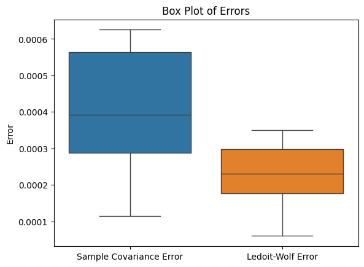

```python
sns.boxplot(
    data = pd.DataFrame({
        'Sample Covariance Error': sample_errors,
        'Ledoit-Wolf Error': lw_errors
    })
)
plt.title('Box Plot of Errors')
plt.ylabel('Error');
```

### Thêm Nhiều Tài Sản

Bây giờ chúng ta sẽ áp dụng điều này cho nhiều tài sản hơn trong một khoảng thời gian dài hơn. Hãy xem cách mà các lỗi thay đổi qua một loạt các tháng.

```python
start_date = '2024-11-01'
end_date = '2025-04-01'

VN30 = "ACB,BCM,BID,BVH,CTG,FPT,GAS,GVR,HDB,HPG,LPB,MBB,MSN,MWG,PLX,SAB,SHB,SSB,SSI,STB,TCB,TPB,VCB,VHM,VIB,VIC,VJC,VNM,VPB,VRE".split(',')

prices = get_prices(*VN30, start_date=start_date, end_date=end_date)
returns = prices.pct_change()[1:]

dates = returns.resample('ME').first().index
```

Ở đây chúng ta tính toán các ước lượng hiệp phương sai khác nhau:

```python
sample_covs = []
lw_covs = []

for i in range(1, len(dates)-1):
    sample_cov = returns[dates[i-1]:dates[i]].cov().values
    sample_covs.append(sample_cov)

    lw_cov = covariance.ledoit_wolf(returns[dates[i-1]:dates[i]])[0]
    lw_covs.append(lw_cov)
```

Ở đây, chúng ta tính toán sai số cho từng khoảng thời gian.

```python
lw_diffs = []
for pair in zip(lw_covs[:-1], lw_covs[1:]):
    diff = np.mean(np.sum(np.abs(pair[0] - pair[1])))
    lw_diffs.append(diff)

sample_diffs = []
for pair in zip(sample_covs[:-1], sample_covs[1:]):
    diff = np.mean(np.sum(np.abs(pair[0] - pair[1])))
    sample_diffs.append(diff)
```

Và biểu diễn chúng theo thời gian trên biểu đồ

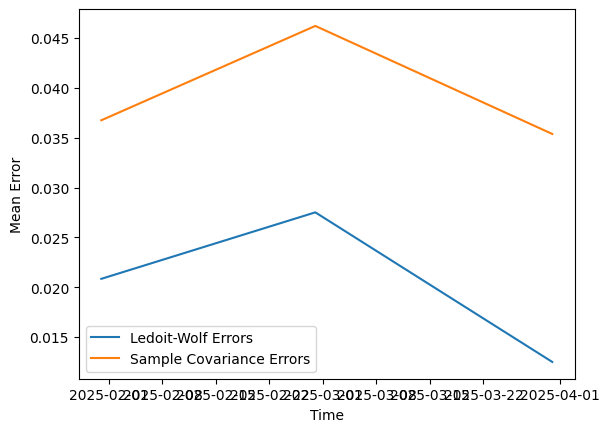

```python
plt.plot(dates[2:-1], lw_diffs)
plt.plot(dates[2:-1], sample_diffs)
plt.xlabel('Time')
plt.ylabel('Mean Error')
plt.legend(['Ledoit-Wolf Errors', 'Sample Covariance Errors']);
```

Chúng ta có thể thấy rằng sai số trung bình của Ledoit-Wolf thấp hơn so với sai số của ma trận hiệp phương sai mẫu. Điều này cho thấy rằng ma trận hiệp phương sai mẫu kém ổn định hơn. Ví dụ này chỉ sử dụng 30 tài sản, nhưng khi chúng ta thêm nhiều tài sản hơn, ước lượng Ledoit-Wolf có khả năng sẽ hoạt động tốt hơn nữa khi số lượng tài sản vượt qua số lượng quan sát.

*Lưu ý: Tài liệu này mang tính chất chia sẻ kiến thức khoa học dữ liệu. Các mã chứng khoán xuất hiện trong tài liệu chỉ mang tính chất minh hoạ, không khuyến nghị đầu tư. Chúng tôi không chịu trách nhiệm trước mọi rủi ro nào do sử dụng tài liệu này.*